# GAN that generates images similar to MNIST dataset

The goal of this lecture is to implement a generative adversarial network (GAN) in Tensorflow that learns to generate images similar to the MNSIT dataset.

### Course of Action

- Please write all executable python code in `Code`-Cells (`Cell`->`Cell Type`->`Code`) and all Text as [Markdown](http://commonmark.org/help/) in `Markdown`-Cells
- Describe your thinking and your decisions (where appropriate) in an extra Markdown Cell or via Python comments
- In general: discuss all your results and comment on them (are they good/bad/unexpected, could they be improved, how?, etc.). Furthermore, visualise your data (input and output).
- Write a short general conclusion at the end of the notebook
- Further experiments are encouraged. However, don't forget to comment on your reasoning.
- Use a scientific approach for all experiments (i.e. develop a hypothesis or concrete question, make observations, evaluate results)

### Submission

E-Mail your complete Notebook to maucher@hdm-stuttgart.de until the start of the next lecture. One Notebook per Group is enough. Edit the teammember table below.

**Important**: Also attach a HTML version of your notebook (`File`->`Download as`->`HTML`) in addition to the `.ipynb`-File.

| Teammember |  |
| --- | --- |
| 1. | Christopher Caldwell |
| 2. | Fabian Müller |
| 3. | An Dang |

## Prerequisities

1. Make sure you have a general understanding how GANs are able to produce realistic looking images. A good practice-oriented overview of the theory is given in the [DCGAN Notebook](http://nbviewer.jupyter.org/urls/maucher.home.hdm-stuttgart.de/nb/ML/DCGAN.ipynb) from the [Machine Learning](http://maucher.pages.mi.hdm-stuttgart.de/ai/page/ml/) lecture. A more theoretical overview is given in the [paper](https://arxiv.org/pdf/1701.00160.pdf) for the NIPS 2016 Workshop on GANs. Specifically make sure you understand the following concepts:
   - How the generator and discriminator work together to produce realistically looking images
   - What the discriminator and generator use as input
2. Make sure to have the following python libraries installed (e.g. via `pip install`)
   - tensorflow
   - numpy
   - matplotlib

## The MNIST Dataset

By now you should be fairly familiar with the MNIST Dataset. This time, we normalize the input images right after loading so we can feed a normalized input to the model later on.

#### Tasks:

- Load the dataset, normalize the images and display one entry as an inline image

#### Hint:

- use the jupyter magic command [`%matplotlib`](http://ipython.readthedocs.io/en/stable/interactive/magics.html#magic-matplotlib) to activate the inline backend

```python
import tensorflow as tf
import numpy as np
import matplotlib.pyplot as plt
%matplotlib inline

tf.reset_default_graph()
```

For more accurate results in this excersise, we combined the training set with the test set to achieve a higher number of real images. IN this case 60000 images from the training set and 10000 images from the test set.

[output not shown]

[output cut: 88 more lines]

[output not shown]

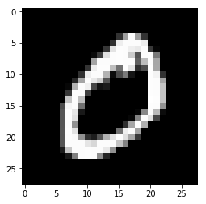

```python
from tensorflow.keras.datasets.mnist import load_data
(train_X, train_y),(test_X, test_y) = load_data()

train_X = train_X/255.0
train_y = train_y/255.0

test_X = test_X/255.0
test_y = test_y/255.0


train = np.append(train_X, test_X, axis=0) #Use both Train and Testset for GAN

print(train.shape)

image = train[1]

print(image.shape)
print(image.dtype)
plt.imshow(image.reshape(28,28), cmap='gray')

print(image)
```

## Discriminator

The discriminator has the job to differentiate if an image is generated or a real sample from the dataset. For this the GAN will use a relativley simple CNN architecture. This part of the network should therefore accept *MNIST-shaped* images (28x28). The network should have the following layers:

1. **`Input`**: accepts 28px x 28px monochromatic images
2. **`1st convolution`**: filtersize 5x5, 32 features, `SAME` padding, ReLU Activation
3. **`Average Pooling`**: 2x2 kernel, 2x2 stride
4. **`2nd convolution`**: fitersize 5x5, 64 features, `SAME` padding, ReLU Activation
5. **`Average Pooling`**: 2x2 kernel, 2x2 stride
6. **`1st fully-connected`**: 1024 neurons, ReLU activation
7. **`2nd fully-connected`**: $K$ neurons, sigmoid activation

Note that the final layer should have a sigmoid activation function. This is a natural choice, since the discriminator should use [cross entropy](https://en.wikipedia.org/wiki/Cross_entropy) loss during training and therefore should output a probability distribution. However, Tensorflow [discourages](https://github.com/tensorflow/tensorflow/issues/2462) the use of the sigmoid activation function when using it as a part of calculating cross entropy. Instead it provides the [`sigmoid_cross_entropy_with_logits`](https://www.tensorflow.org/api_docs/python/tf/nn/sigmoid_cross_entropy_with_logits) function which expects unscaled logits as input and calculates the cross-entropy in an optimized and numerically stable fashion. However, this function expects the target distribution (the *labels*) as a second parameter.

To keep things easy, you could pass the labels as a [`tf.placeholder`](https://www.tensorflow.org/api_docs/python/tf/placeholder) and supply them during training. However, since there are only 2 possible labels (real or fake) and we know, depending on the input, all labels, it is actually easier to return the unscaled outputs for now and calculate the cross-entropy later.

#### Tasks:

- what is the value of $K$ in the output layer?
- write a function `discriminator` that expects an `images` parameter. The images parameter is the input to the network and can either be the output of the generator or a real image. The function builds the network and returns the unscaled output

#### Hint:

You later need to be able to call the discriminator function multiple times (once to pass the *real image* placefolder, once to pass the *generator output* as input. However, you do not want multiple discriminators, otherwise one discriminator would be trained to only predict images as fake and another to only predict images as real. Therefore, we need to make sure Tensorflow reuses all variables (weights and biases) that are adjusted during training.

- use a [`tf.variable_scope`](https://www.tensorflow.org/api_docs/python/tf/variable_scope) to which all discriminator variables are added.
- use [`tf.get_variable`](https://www.tensorflow.org/api_docs/python/tf/get_variable) to get an existing, named variable or create a new one.
- add another parameter to the `discriminator` function to specify if variables should be reused or not
- depending on this parameter, use [`VariableScope.reuse_variables()`](https://www.tensorflow.org/api_docs/python/tf/VariableScope#reuse_variables) on the scope to make sure tensorflow reuses all variables and does not create new ones.

[figure not shown]

```python
def discriminator(X, reuse_vars=None):
    with tf.variable_scope('dis', reuse=reuse_vars):

        conv1 = tf.layers.conv2d(inputs=X, filters=32, kernel_size=[5,5], padding="same", activation=tf.nn.relu, name="conv1")

        pool1 = tf.layers.average_pooling2d(inputs=conv1, pool_size=[2,2], strides=2, name="pool1")

        conv2 = tf.layers.conv2d(inputs=pool1, filters=64, kernel_size=[5,5], padding="same", activation=tf.nn.relu, name="conv2")

        pool2 = tf.layers.average_pooling2d(inputs=conv2, pool_size=[2,2], strides=2, name="pool2")

        flat_layer = tf.reshape(pool2, [-1, 7 * 7 * 64], name="flatten")

        # Dense layer
        dense = tf.layers.dense(inputs=flat_layer, units=1024, activation=tf.nn.relu, name="dense")

        # Logits layer
        logits = tf.layers.dense(inputs=dense, units=1, name="dense2")

        output = tf.sigmoid(logits, name="sigmoid")

        return output, logits
```

## Generator

The generator has the job to produce realistic looking images to ultimatley deceive the discriminator. To succeed in this task, the generator takes a noise vector as input, upsamples it and, through multiple layers of convolution, shapes this noise to have the same distribution as the samples from the dataset.

The generator should have the following architecture:

1. **`Input`**: accepts a noise vector of length $N$
2. **`1st fully-connected`**: upsamples the input vector to length $L$, applies ReLU activation function
3. **`1st convolutional`**: filtersize 3x3, 2x2 strides, $N/2$ features, `SAME` padding, ReLU activation
4. **[`BatchNormalization`](https://www.tensorflow.org/api_docs/python/tf/keras/layers/BatchNormalization)**: using the default parameters
5. **`upsample`**: factor 2x2, bilinear
6. **`2nd convolutional`**: filtersize 3x3, 2x2 strides, $N/4$ features, `SAME` padding, ReLU activation
7. **`BatchNormalization`**: using the default parameters
8. **`upsample`**: factor 2x2, bilinear
9. **`3rd convolutional`**: filtersize 3x3, 2x2 strides, 1 feature, sigmoid activation

The final layer only outputs one feature. This is the generated image. The sigmoid activation function maps the unscaled output to values in the interval [0, 1] (one gray channel).

#### Tasks:

- what is the value of $L$, the number of neurons in the upscaling layer?
- implement the `generator()` function that expects an input noise vector of size $N$ and returns the the operation to calculate the sigmoid-scaled output of the sub-network.
- test the generator by generating a test image from a noise vector. Use $N = 100$.

#### Hint:

- use a [`tf.variable_scope`](https://www.tensorflow.org/api_docs/python/tf/variable_scope) to which all generator variables are added.
- use the [`tf.reshape`](https://www.tensorflow.org/api_docs/python/tf/reshape) function to reshape the upscaled 3D tensor with shape [batch_size, $L$, 1] to a 4D tensor with shape [batch_size, $\sqrt L$, $\sqrt L$, 1] before feeding it into the subsequent convolutional layers
- use the helper function [`tf.image.resize_images`](https://www.tensorflow.org/api_docs/python/tf/image/resize_images) to resize (upsample) a whole batch of 4D tensors using bilinear interpolation.
- You can test the generator in a [`tf.Session`](https://www.tensorflow.org/api_docs/python/tf/Session) and feeding it a noise vector of length $N$. The output can be visualized using the [`imshow`](https://matplotlib.org/api/_as_gen/matplotlib.pyplot.imshow.html) function from matplotlib. Don't forget to **remove the constructed generator network from the default graph** using [`tf.reset_default_graph()`](https://www.tensorflow.org/api_docs/python/tf/reset_default_graph) or to instantiate it in a new graph.

[figure not shown]

```python
def gen(noise, reuse_vars=None):
    with tf.variable_scope("gen", reuse=reuse_vars):
        # First DenseLayer
        dense = tf.layers.dense(inputs=noise, units=3136, activation=tf.nn.relu, name="dense")


        #Reshape
        reshape = tf.reshape(dense, [-1, 56, 56, 1], name="reshape")


        #1 Conv2d
        conv1 = tf.layers.conv2d(inputs=reshape, filters=50, kernel_size=[3,3], strides=2, padding="same", activation=tf.nn.relu, name="conv1")

        #BatchNormalization
        conv1_norm = tf.layers.batch_normalization(conv1, name="batch_norm1")

        #Upsample
        conv1_upsample = tf.image.resize_images(conv1_norm, (56,56))


        #2 Conv2d
        conv2 = tf.layers.conv2d(inputs=conv1_upsample, filters=25, kernel_size=[3,3], strides=2, padding="same", activation=tf.nn.relu, name="conv2")

        #BatchNormalization
        conv2_norm = tf.layers.batch_normalization(conv2, name="batch_norm2")

        #Upsample
        conv2_upsample = tf.image.resize_images(conv2_norm, (56,56))


        #2 Conv2d
        logits = tf.layers.conv2d(inputs=conv2_upsample, filters=1, kernel_size=[3,3], strides=2, padding="same", name="conv3")

        output = tf.nn.sigmoid(logits, name="sigmoid")
        return output
```

> Perhaps use Leaky Relu as activation function to improve: To use Leaky Relu, we simply call

> tf.nn.leaky_relu(input tensor, alpha=0.2, name="optional")

## Building the GAN

Now that the generator and discriminator architecture is build, the pieces need to be plugged together.

#### Tasks:

- Create the [`tf.placeholder`](https://www.tensorflow.org/api_docs/python/tf/placeholder)s for feeding the real images `x` and the noise vector `z`
- instantiate the generator `Gz`
- instantiate the discriminator `Dx` for the real data and `Dg` for the generated data (make sure to set `reuse=True` in the second call to the discriminator function to reuse all variables

[figure not shown]

```python
tf.reset_default_graph()
```

```python
with tf.name_scope('input'):
    real_images = tf.placeholder(tf.float32, shape=[None, 28,28,1], name="ImagePlaceholder")
    z = tf.placeholder(tf.float32, shape=[None, 100], name = "NoisePlaceholder")
```

```python
Gz = gen(z)
```

[output not shown]

```python
D_output_real, D_logits_real = discriminator(real_images)
D_output_fake, D_logits_fake = discriminator(Gz, reuse_vars=True)
```

```
WARNING:tensorflow:From <ipython-input-3-faafc710fd02>:6: average_pooling2d (from tensorflow.python.layers.pooling) is deprecated and will be removed in a future version.
Instructions for updating:
Use keras.layers.average_pooling2d instead.
```

## Training the GAN

Later, the discriminator and generator should be trained separately. In the last notebook you learned how to use [`tf.train.Optimizer`](https://www.tensorflow.org/api_docs/python/tf/train/Optimizer)s to minimize a loss function by using stochastic gradient descent (SGD).

In a GAN network, the discriminator tries to minimize it's loss, meaning it is trained to be good at discriminating real from fake data. However, the generator tries to maximize the loss of the discriminator, meaning it is able to generate data that *looks* real to the discriminator. Thus, it's loss is minimal if the discriminator outputs the wrong label for data from the generator.

#### Tasks:

- create the operations to calculate the cross-entropy for `Dx`, `Dg` and `Gz`

#### Hint:

- use [`tf.nn.sigmoid_cross_entropy_with_logits`](https://www.tensorflow.org/api_docs/python/tf/nn/sigmoid_cross_entropy_with_logits) to calculate the cross-entropy and [`tf.reduce_mean`](https://www.tensorflow.org/api_docs/python/tf/reduce_mean) to calculate the mean loss over a whole mini-batch.
- use [`tf.ones_like()`](https://www.tensorflow.org/api_docs/python/tf/ones_like) and [`tf.zeros_like()`](https://www.tensorflow.org/api_docs/python/tf/ones_like) to create the labels for `Dx` and `Dg` in the same shape as the unscaled logits from the discriminator

```python
# LOSSES
def loss_func (logits_in, labels_in):
    return tf.reduce_mean(tf.nn.sigmoid_cross_entropy_with_logits(
    logits=logits_in, labels=labels_in, name="CrossEntropy"), name="ReduceMean")
```

```python
D_real_loss = loss_func(D_logits_real, tf.ones_like(D_logits_real, name="Generator_Label"))
D_fake_loss = loss_func(D_logits_fake, tf.zeros_like(D_logits_fake, name="Discriminator_Label"))

D_loss = D_real_loss + D_fake_loss
```

```python
G_loss = loss_func(D_logits_fake, tf.ones_like(D_logits_fake, name="Generator_TrickLabel"))
```

> For the Discriminator, we can also try out smoothing, by multiplying the ones with a smoothing factor (perhapts 0.9)

The cross-entropy loss of the discriminator and generator can now be used to train the network using an optimizer that performs SGD, however the generator should not be able to adjust weights of the discriminator during training. Otherwise it would not learn to deceive the discriminator, but only prevent it from learning good rules. Likewise the discriminator should not be able to modify the weights of the generator for the same reason.

#### Tasks:

- Create [`AdamOptimizer`](https://www.tensorflow.org/api_docs/python/tf/train/AdamOptimizer)s that minimize the loss of `Dx`, `Dg` and `Gz` that will only adjust the weights of either the generator or discriminator.

#### Hint:

- use [`tf.trainable_variables(scope='')`](https://www.tensorflow.org/api_docs/python/tf/trainable_variables) to get a list of all variable in a named variable scope
- use an [`AdamOptimizer`](https://www.tensorflow.org/api_docs/python/tf/train/AdamOptimizer) with a learning rate of `0.0003` for the discriminator and a learning rate of `0.0001` for the generator
- use the `var_list` argument of the [`minimize`](https://www.tensorflow.org/api_docs/python/tf/train/AdamOptimizer#minimize) function to restrict the variables that are adjusted during training.

```python
D_learning_rate = 0.0003
G_learning_rate = 0.0001

# learning_rate = 0.001 - worked so far better
```

```python
d_vars = tf.trainable_variables(scope='dis')
g_vars = tf.trainable_variables(scope='gen')
```

```python
D_trainer = tf.train.AdamOptimizer(D_learning_rate, name="AdamOptimizer_Discriminator").minimize(D_loss, var_list=d_vars, name="minimize_D_loss")
```

```python
G_trainer = tf.train.AdamOptimizer(G_learning_rate, name="AdamOptimizer_Discriminator").minimize(G_loss, var_list=g_vars, name="minimize_G_loss")
```

To be able to supervise the training process, use the [`tf.summary`](https://www.tensorflow.org/api_docs/python/tf/summary) helpers to log data during training to display in a tensorboard.

#### Tasks:

- add summaries for all losses
- add an operation to generate 5 images to the summaries
- create a merged operation for all summaries and a writer to write them to disk

#### Hint:

- use [`tf.summary.scalar`](https://www.tensorflow.org/api_docs/python/tf/summary/scalar) for scalar values
- use [`tf.summary.image`](https://www.tensorflow.org/api_docs/python/tf/summary/image) for generated images
- use a [`FileWriter`](https://www.tensorflow.org/api_docs/python/tf/summary/FileWriter)to write the summaries to disk
- choose an output path like `./tensorboard/<current time>/`, then the tensorboard gui can automatically differentiate between different runs of your model if started with `--logdir ./tensorboard/`

```python
tf.summary.scalar("Dx_Loss", D_real_loss)
tf.summary.scalar("Dg_Loss", D_fake_loss)
tf.summary.scalar("D_loss", D_loss)
tf.summary.scalar("G_loss", G_loss)

tf.summary.image("Generated_Images", Gz, max_outputs=5)
```

```
<tf.Tensor 'Generated_Images:0' shape=() dtype=string>
```

> For naming the tensorboard, we used a timestamp

```python
import datetime

now = datetime.datetime.now()
```

Now it's finally time to train the model and generate new images. However, it is advantageous to pre-train the discriminator before training the generator, so the discriminator has a headstart and *an approximate idea* what real data looks like.

#### Tasks:

- pre-train the discriminators with 20,000 images using mini-batches with real and fake data
- train the discriminator and generator for min. 5,000,000 images
- write your summary every 10 steps
- after every training of 500,000 (10% of total training) images, generate a sample image and display it inline in the notebook
- also print all losses (from `Dx`, `Dg` and `Gx`) after each 10th of the training process

#### Hint:

- don't forget to create a new session and initialize all variables before running any operations
- check the output of your tensorboard to see how the generated images develop during the training.
- don't forget to close the session when done (or use a [context manager](https://www.tensorflow.org/api_docs/python/tf/Session))

#### Tips:

- to visualize the progress during training, check out the really useful [`tqdm`](https://github.com/tqdm/tqdm) library
- to create the training batches, use the same `Dataset` pipeline or your custom logi as in the previous experiment
- the training can take a very long time on your local machine. After making sure everything works as intended you can run the model on the [Deeplearn Machines @ HdM](https://wiki.mi.hdm-stuttgart.de/wiki/Deep_Learning).
- to speed up training, play around with the mini-batch size. Generally make it as big as possible but avoid running out of memory on your GPU and avoid using swap when training on the CPU as this will slow training down.
- use anaconda command to install tqdm:

  > conda install -c conda-forge tqdm

> We used a batch size of 100 images. This is also a hyperparameter that can be tested. For the Buffersize we used double of our real images amount (70000 * 2 = 140000)

> In order to run over 5 million images we used 50000 epochs of a batch size of 100  
> 50000 * 100 = 5 million

```python
BATCH_SIZE = 100

BUFFER_SIZE = 140000

EPOCHS = 50000
```

> Create an empty array for the sample images

```python
samples = []
#real = []
```

```python
#Adding config for GPU - not using all of the GPUs Memory -> leading to crashes
config = tf.ConfigProto()
config.gpu_options.allow_growth = True
config.gpu_options.per_process_gpu_memory_fraction = 0.8

merged = tf.summary.merge_all()
```

```python
from tqdm import tqdm

train = train.reshape(train.shape[0], 28, 28, 1).astype('float32')

train_dataset = tf.data.Dataset.from_tensor_slices(train).repeat().shuffle(BUFFER_SIZE).batch(BATCH_SIZE)

iterator = train_dataset.make_one_shot_iterator()

nextbatch = iterator.get_next()

init = tf.global_variables_initializer()
```

```
0.8194157192019427
Discriminator-Real-Loss: 3.102825e-06
Discriminator-Fake-Loss: 1.2074692e-06
Discriminator Loss: 4.310294e-06
Generator Loss: 13.631067
```

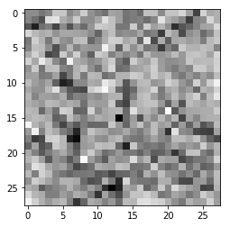

```
0.2806021219839341
Discriminator-Real-Loss: 2.2764112e-14
Discriminator-Fake-Loss: 8.190484e-08
Discriminator Loss: 8.190486e-08
Generator Loss: 16.317572
```

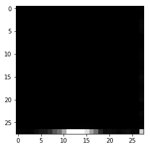

```
0.04155540148076017
Discriminator-Real-Loss: 0.060283437
Discriminator-Fake-Loss: 0.071182154
Discriminator Loss: 0.13146558
Generator Loss: 3.0054748
```

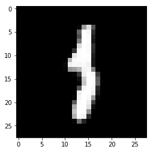

```
0.6971578848054449
Discriminator-Real-Loss: 0.11282771
Discriminator-Fake-Loss: 0.08900915
Discriminator Loss: 0.20183685
Generator Loss: 4.5267196
```

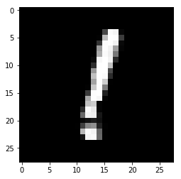

```
-0.07983010910499816
Discriminator-Real-Loss: 0.19534263
Discriminator-Fake-Loss: 0.03628649
Discriminator Loss: 0.23162912
Generator Loss: 3.4306738
```

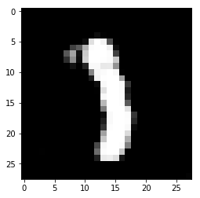

```
-0.06751430526400064
Discriminator-Real-Loss: 0.10367917
Discriminator-Fake-Loss: 0.10281411
Discriminator Loss: 0.20649329
Generator Loss: 2.7797167
```

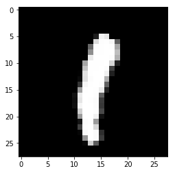

```
-0.40474908136485577
Discriminator-Real-Loss: 0.25534055
Discriminator-Fake-Loss: 0.060463306
Discriminator Loss: 0.31580386
Generator Loss: 3.4139051
```

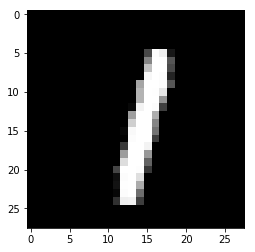

```
1.2017464702439755
Discriminator-Real-Loss: 0.20318653
Discriminator-Fake-Loss: 0.056507602
Discriminator Loss: 0.25969413
Generator Loss: 3.2276068
```

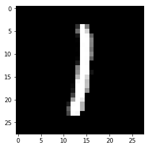

```
-0.46264170603657634
Discriminator-Real-Loss: 0.061275493
Discriminator-Fake-Loss: 0.03516896
Discriminator Loss: 0.09644446
Generator Loss: 3.912984
```

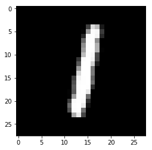

```
0.25179898452303073
Discriminator-Real-Loss: 0.044046707
Discriminator-Fake-Loss: 0.058589865
Discriminator Loss: 0.102636576
Generator Loss: 3.768706
```

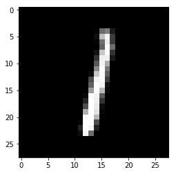

```python
with tf.Session(config=config) as sess:
    sess.run(init)

    # Naming the different Tensorboards. Additionally to the date, we added a shot description of the current model
    writer = tf.summary.FileWriter('./tensorboard/{0}_GAN'.format(now.strftime("%Y_%m_%d-%H-%M")), sess.graph)

    # Pretrain Epochs for Discriminator. For 20000 images we need 200 Epochs with a batch size of 100
    for pretrain in tqdm(range(200)):
        batch_images = sess.run(nextbatch)

        # We used random normal distribution with standard deviation of 0.5 -> Explanation below
        batch_z =  np.random.normal(0.0, 0.5, size=(BATCH_SIZE,100))

        _ = sess.run(D_trainer, feed_dict={real_images:batch_images, z:batch_z})


    for epoch in tqdm(range(EPOCHS)):

        batch_images = sess.run(nextbatch)

        # We used random normal distribution with standard deviation of 0.5 -> Explanation below
        batch_z = np.random.normal(0.0, 0.5, size=(BATCH_SIZE,100))

        D_summary, _, discrloss, discr_r_loss, discr_f_loss = sess.run([merged, D_trainer, D_loss, D_real_loss, D_fake_loss], feed_dict={real_images:batch_images, z:batch_z})

        genloss, _ = sess.run([G_loss, G_trainer], feed_dict={z:batch_z})

        if (epoch % 10 == 0):{
            # SUMMARIES
            writer.add_summary(D_summary, epoch)
        }


        if (epoch%5000 == 0):
            # We used random normal distribution with standard deviation of 0.5 -> Explanation below
            #sample_z = np.random.uniform(0,1,size=(1,100))
            sample_z = np.random.normal(0.0, 0.5, size=(1,100))

            # We printed out a normal distributed sample value to see if the values are between -1 and 1
            print(sample_z[0][0])


            # Print out all losses
            print("Discriminator-Real-Loss:", discr_r_loss)

            print("Discriminator-Fake-Loss:", discr_f_loss)

            print("Discriminator Loss:",discrloss)

            print("Generator Loss:",genloss)

            # Generate a sample image
            gen_sample = sess.run(gen(z, reuse_vars=True), feed_dict={z: sample_z})

            samples.append(gen_sample)

            # Display the sample image at current epoch
            plt.imshow(gen_sample.reshape(28,28), cmap="gray")
            plt.show()
```

# Conclusion

## Suggested GAN from excersise

At first we tried out the GAN as suggested from the exercise. Here we see three example runs of the code above:

## Losses of Discriminator and Generator

### Discriminator Loss:

[figure not shown]

### Discriminator Real Loss:

[figure not shown]

### Discriminator Fake Loss:

[figure not shown]

### Generator Loss:

[figure not shown]

### First Run (ORANGE)

In our first run, we can clearly see that the Generator loss increases during the entire training process.

As a result, no numbers are generated. The images stay black.

### Second Run (BLUE)

Even though we haven't changed anything in the code from the first run, the losses of the Generator and Discriminator converge just as we wanted.

As a result, numbers are generated.

### Third Run (RED)

Again, we can clearly see, that the Generator loss increases during the entire training process.

And yet again, no images are created.

> We tried out many different times, also playing around with the standard deviation of the normal distributed noise feed into the generator and came to the following conclusion.
- This suggested GAN model is very fragile. To achieve a working model, we had to try out the same model twice or three times, without any changes to the code
- Using a standard deviation between 0.5 and 0.1 increased the possibility for the model to generate images
- At the first epoch, a noisy image is generated. At the begining of the training process (the first 100 Epochs) this randomly generated image turns darker and darker. Most of the images stay almost completely black. Only the last column and last row have some random noise. During a training process that does come to a certain point where numbers are generated, this observation can seen increasingly. It goes so far, that only the last Pixel gets highlighted (last row and last column)

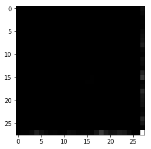

```python
import matplotlib.image as mpimg
import matplotlib.pyplot as plt
plt.imshow(mpimg.imread('gan-black.png'), cmap="gray")
plt.show()
```

- If the training process comes to a certain point where it can generate numbers, the loss of the generator suddenly starts dropping. After this moment, the generator and discriminator successfully compete one another and learn from one another
- Another observation we made is that once the generator has created a number successfully, it stays at the same digit and further on generates only the same digit or perhaps a similar digit. For example a 3 and an 8 are similar.

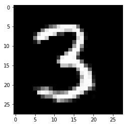

```python
plt.imshow(mpimg.imread('3.png'), cmap="gray")
plt.show()
```

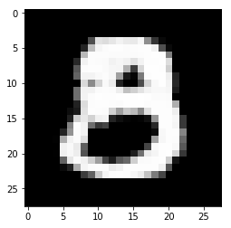

```python
plt.imshow(mpimg.imread('8.png'), cmap="gray")
plt.show()
```

- As suggested during class, we should use a normal distributed noise as input for the generator. At first we tried it with a standard deviation of 1.0 and mean value of 0.0. With this configuration, after mutliple times, no images could be generated. The images stayed black. -> Before using normal distributed random values, we had a uniform random scattering. This seemed to have created more runs, that worked out creating generated images. But it also only generated a single digit or similar digits.
- We also tried out different learning rates for the generator (0.001 instead of 0.0001) with no success.
- We also tried to decrease the initial pretraining of the discriminator and even skipped this pretraining sometimes. This had no effect on the stability of the training process.
- Other than that, we also tried out to smooth the discriminator loss, by multiplying the labels (1) with 0.9. Again, no changes could be seen.

# Modifying the GAN

## Smoothing CYAN

In order to use smoothing we multiplied the labels for the discriminator real loss with 0.9.

## Uniform Distributed Noise MAGENTA

We used uniform distributed random values between -1 and 1

### Discriminator Loss:

[figure not shown]

### Discriminator Real Loss:

[figure not shown]

### Discriminator Fake Loss:

[figure not shown]

### Generator Loss:

[figure not shown]

# Further Experiments

- Trying out different Standard Deviations
- Using Leaky Relu as Activation Function

## Further Ideas

### Change the Loss Function to Wasserstein Distance

[Wasserstein GANs (WGAN)](https://arxiv.org/pdf/1701.07875.pdf) are an alternative to *classical* GANs. They use a different loss function and prooved to be more stable to hyperparameter selection. While the paper offers a good theoretical introduction and reasoning why they perform better in many cases, [this article](https://wiseodd.github.io/techblog/2017/02/04/wasserstein-gan/) provides a good practical introduction